# Hackathon-IE6600-SEC03-GROUP14

Dhruv Merchant

2/19/2022

# Introduction and Problem Statement:

Be it a start-up or an established company, compensation is one of the most important things to maintain for the company in order to reward and retain it’s employees. A lot of start-ups are unsure whether they are paying their employees correctly.A compensation strategy is important for all organizations. It should be well structured and reasonable. From the San Francisco Employee Compensation Data set, we plan to visualize the pay structure in different organizations from 2013 till 2021. The major areas focused are the salary changes over years in San Francisco. It also focuses on how the salary differentiates from high rank and low rank employees and what are the benefits received by the high rank employees in some of the job families.

The San Francisco Employee Compensation Data consists of useful information from which valuable insights can be derived. Within the “Organization Group”, there are seven organizations in San Francisco. We will find out the most number of organization groups since 2013 and try to visualize change in those number of organization groups from 2013 to 2021. These organisations are divided into “Departments” which are primary organizational unit by city and county of San Francisco. These departments are further divided into “Job Families” and “Job types”. Job Families are the job fields of a particular major and Job Titles are the job roles within the families. The salaries, benefits and total compensation are the last columns in the data set from where we find the average salaries for Job families and Job type.

# Organizational Data:

# Question 1: What are the most number of Organizations in San Francisco? How have the number of organizations changed over years from 2013 to 2021?

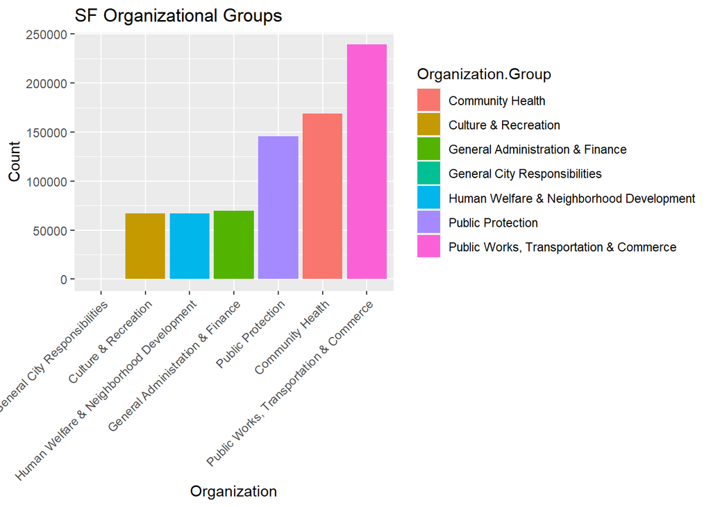

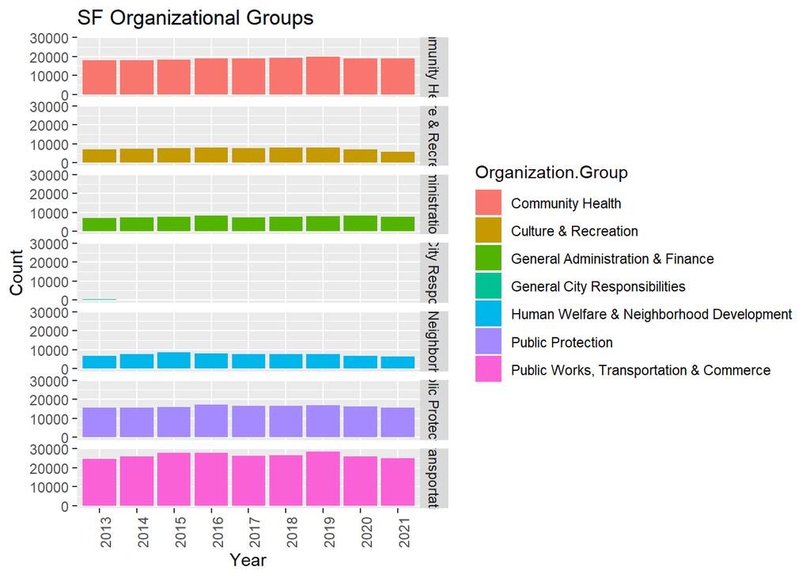